# GO analysis Fig 4

Liz Hughes and Edward Wallace

07/01/2022

# Summary

This document is an analysis of the Gat201 RNA-seq dataset, focusing on differences GO terms up and down regulated in WT at 4 hours for fig 4 multi panel.

A later goal is lists of Gat201-DEGs for analysis of GO terms.

# Load packages used for analysis

# Load GO analysis data

Up and Down regulated DEG lists comparing WT v Gat201 deletion at 4 hours was uploaded into fungi db to create a search strategy.

Analyze Results > Gene Ontology Enrichment > select BP, MF or CC > Submit

Open in Revigo > Select Large, P Value, Yes, Whole UniProt database, SimRel > Start Revigo

Export to R script for plotting > save one.data file

e.g. readr::write_tsv(one.data , “../GOresults/UR4_WT_BP.csv”)

Save files for each BP, MF and CC analysis and combine them all here before making plot in ggplot2 of All GO terms.

## Up regulated in WT at 4 hours in RPMI

```r
BP_Up <- readr::read_tsv("../GOresults/UR4_WT_BP.csv")
MF_Up <- readr::read_tsv("../GOresults/UR4_WT_MF.csv")
CC_Up <- readr::read_tsv("../GOresults/UR4_WT_CC.csv")
```

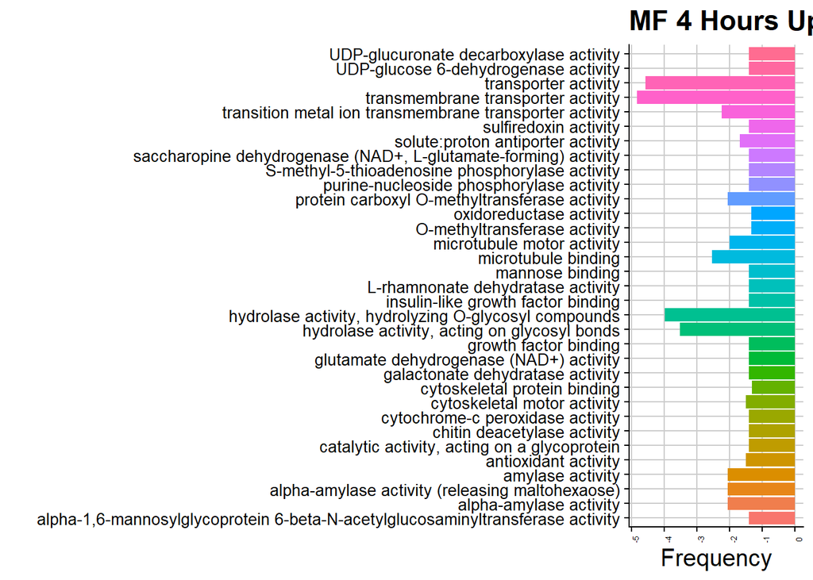

```r
UR4_WT_MF <- ggplot(MF_Up, aes(value,description,  fill = description))+
  theme(legend.position ="none")+
  geom_bar(stat = "identity")+
  labs(title = "MF 4 Hours Up RPMI",
       x = "Frequency", y = "")+
                  theme(text = element_text(size = 15))+
                  theme(axis.text.x = element_text(size= 5, angle = 90))+
                  scale_color_brewer(palette="Set1")

print(UR4_WT_MF)
```

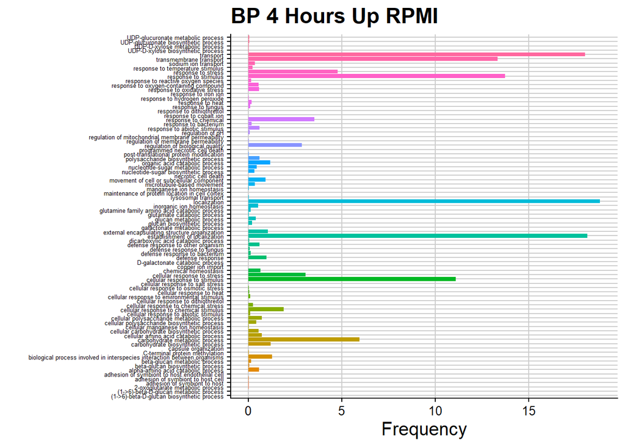

```r
UR4_WT_BP <- ggplot(BP_Up, aes(frequency,description,  fill = description))+
  theme(legend.position ="none")+
  geom_bar(stat = "identity")+
  labs(title = "BP 4 Hours Up RPMI",
       x = "Frequency", y = "")+
                  theme(text = element_text(size = 15))+
                  theme(axis.text.y = element_text(size= 5))+
                  scale_color_brewer(palette="Set1")

print(UR4_WT_BP)
```

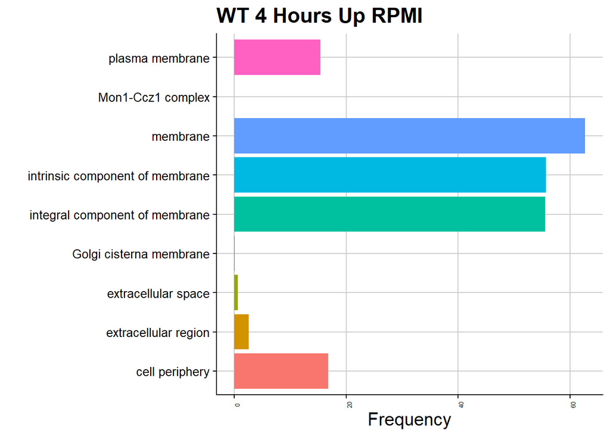

```r
UR4_WT_CC <- ggplot(CC_Up, aes(frequency,description,  fill = description))+
  theme(legend.position ="none")+
  geom_bar(stat = "identity")+
  labs(title = "WT 4 Hours Up RPMI",
       x = "Frequency", y = "")+
                  theme(text = element_text(size = 15))+
                  theme(axis.text.x = element_text(size= 5, angle = 90))+
                  scale_color_brewer(palette="Set1")

print(UR4_WT_CC)
```

```r
UR4_all <- rbind(BP_Up, MF_Up,CC_Up)

UR4_all
```

```
## # A tibble: 126 x 9
##    term_ID    description    frequency   plot_X plot_Y log_size value uniqueness
##    <chr>      <chr>              <dbl>    <dbl>  <dbl>    <dbl> <dbl>      <dbl>
##  1 GO:0006077 (1->6)-beta-D~   0.00491  3.16      5.25     3.07 -2.97      0.803
##  2 GO:0006950 response to s~   4.77    -4.98      1.29     6.06 -5.14      0.796
##  3 GO:0015677 copper ion im~   0.00176  3.79     -5.18     2.63 -1.44      0.964
##  4 GO:0044419 biological pr~   1.26    -1.00      7.07     5.48 -1.38      1
##  5 GO:0044650 adhesion of s~   0.0132  -6.16     -3.95     3.50 -1.33      0.914
##  6 GO:0048878 chemical home~   0.655   -2.55     -6.36     5.20 -1.95      0.846
##  7 GO:0050896 response to s~  13.7     -2.09      7.67     6.52 -4.87      1
##  8 GO:0051179 localization    18.8     -1.29      8.35     6.66 -1.54      1
##  9 GO:0045229 external enca~   1.04    -0.00723  -5.28     5.40 -2.90      0.968
## 10 GO:0097300 programmed ne~   0.00713  0.742    -2.47     3.24 -1.41      0.959
## # ... with 116 more rows, and 1 more variable: dispensability <dbl>
```

```r
readr::write_tsv(UR4_all, "../GOresults/UR4_all.csv")
```

[figure not shown]

```r
UR4_WT_all_Up <- ggplot(UR4_all, aes(frequency,description,  fill = description))+
  theme(legend.position ="none")+
  geom_bar(stat = "identity")+
  labs(title = "WT 4 Hours Up RPMI",
       x = "Frequency", y = "")+
                  theme(text = element_text(size = 20))+
                  theme(axis.text.x = element_text(size= 5, angle = 90))+
                  scale_color_brewer(palette="Set1")

print(UR4_WT_all_Up)
```

```r
ggsave("~/Edward Wallace/Lab based work/RNA Seq/UR4_WT_all.jpg",
       width = 5,height=5)
```

## Down regulated in WT at 4 hours in RPMI

```r
BP_Down <- readr::read_tsv("../GOresults/DR4_WT_BP.csv")
MF_Down <- readr::read_tsv("../GOresults/DR4_WT_MF.csv")
CC_Down <- readr::read_tsv("../GOresults/DR4_WT_CC.csv")
```

```r
DR4_all <- rbind(BP_Down, MF_Down,CC_Down)

DR4_all
```

```
## # A tibble: 71 x 9
##    term_ID    description      frequency plot_X plot_Y log_size value uniqueness
##    <chr>      <chr>                <dbl>  <dbl>  <dbl>    <dbl> <dbl>      <dbl>
##  1 GO:0008643 carbohydrate tr~    0.710   1.86   2.83      5.23 -2.48      1
##  2 GO:0042254 ribosome biogen~    1.70   -6.23   2.40      5.61 -6.97      0.640
##  3 GO:0051409 response to nit~    0.0161  1.46   5.93      3.59 -1.56      0.968
##  4 GO:0016072 rRNA metabolic ~    1.23   -5.49  -3.35      5.47 -5.57      0.639
##  5 GO:1901568 fatty acid deri~    0.0373  0.285 -8.08      3.95 -1.56      0.947
##  6 GO:0006072 glycerol-3-phos~    0.125  -2.29   7.07      4.48 -2.35      0.909
##  7 GO:0006020 inositol metabo~    0.0636  4.26  -3.24      4.19 -1.97      0.846
##  8 GO:0005975 carbohydrate me~    5.94   -2.18  -8.20      6.16 -1.82      0.901
##  9 GO:0046952 ketone body cat~    0.0114  4.31  -0.387     3.44 -1.56      0.792
## 10 GO:0046950 cellular ketone~    0.0137  2.94  -5.49      3.52 -1.56      0.887
## # ... with 61 more rows, and 1 more variable: dispensability <dbl>
```

```r
readr::write_tsv(DR4_all, "../GOresults/DR4_all.csv")
```

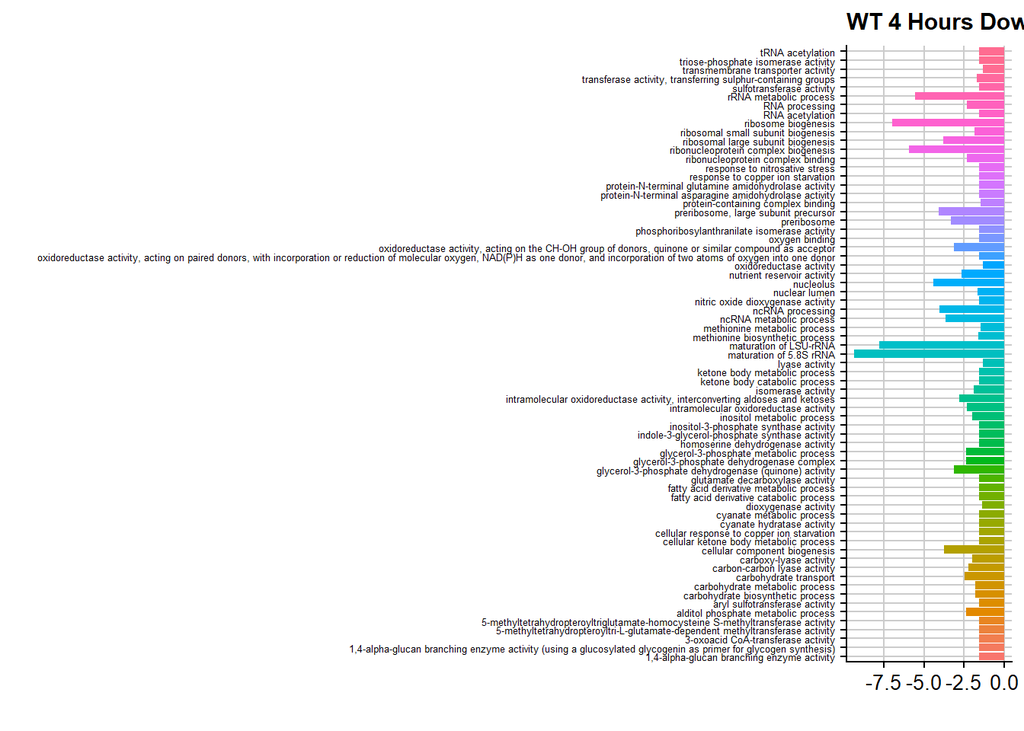

```r
#frequency = The proportion of this GO term in the underlying protein annotatoin dtabase (whole uniprot). A higher frequency indicated more general terms and a lower frequency more specific terms.

DR4_WT_all_Down <- ggplot(DR4_all, aes( value, description, fill = description))+
                  theme(legend.position ="none")+
                  geom_bar(stat = "identity")+

                  labs(title = "WT 4 Hours Down RPMI",
                           x = "",
                           y = "")+
                  theme(text = element_text(size = 10))+
                  theme(axis.text.y = element_text(size = 5))+
                  scale_color_brewer(palette="Set1")

DR4_WT_all_Down
```

# Load GO analysis data2

Up and Down regulated DEG lists comparing WT v Gat201 deletion at 4 hours was uploaded into fungi db to create a search strategy.

Use results tables from fungidb: Go term, no genes, % background genes ( % of my genes of the genes in the background with this term),P-value and adjusted p-value (Bonferroni)

Analyze Results > Gene Ontology Enrichment > select BP, MF or CC (P-Value cuttoff = 0.05) > Submit > download .txt file.

Import .txt file into excell > open document >Data tab > From text/csv > save as .csv file # Up regulated

```r
U4_BP <- readr::read_csv("../GOresults/BP_up4.csv")
U4_MF <- readr::read_csv("../GOresults/MF_up4.csv")
U4_CC <- readr::read_csv("../GOresults/CC_up4.csv")
```

```r
U4_BP['GO_group'] <- "BP"
U4_MF['GO_group'] <- "MF"
U4_CC['GO_group'] <- "CC"
```

## Biological Process

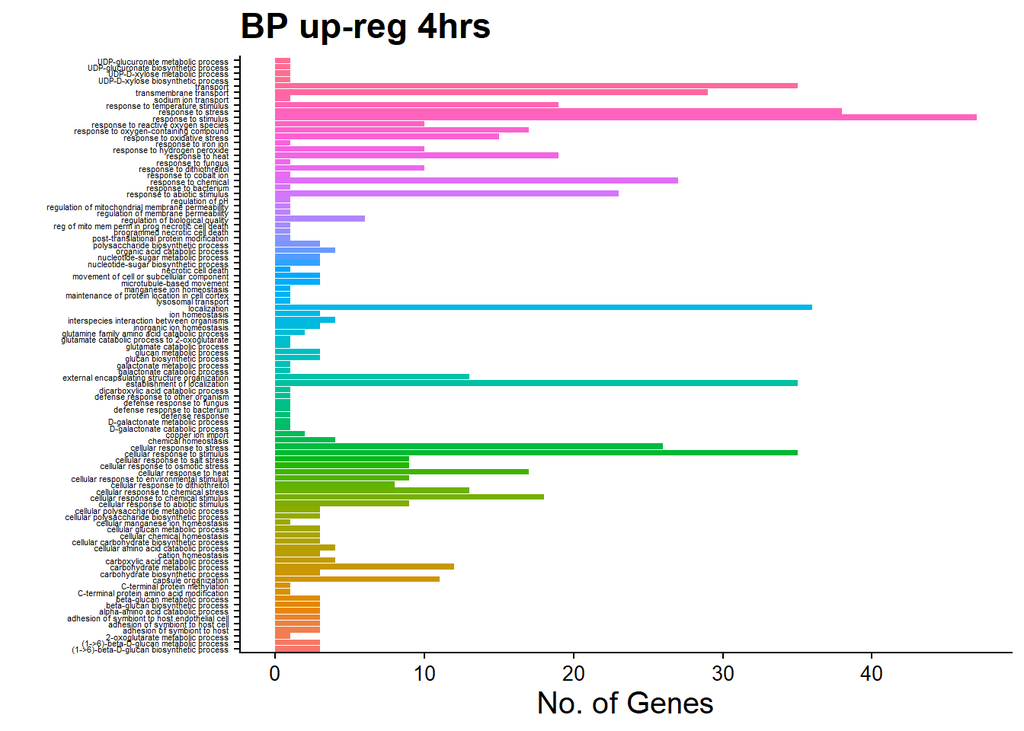

```r
Up4BP <- ggplot(U4_BP, aes(genes,description,  fill = description))+
         geom_bar(stat = "identity")+
                  labs(title = "BP up-reg 4hrs",
                            x = "No. of Genes",
                            y = "")+
          theme(legend.position ="none")+
          theme(text = element_text(size = 15))+
          theme(axis.text.y = element_text(size= 4))+
  theme(
    panel.grid.major = element_blank(),
    panel.grid.minor = element_blank()
  )


print(Up4BP)
```

```r
ggsave("~/GitHub/CryptoGat201RNASeq_draft_b/GOresults/BP_up4.png", width = 8, height = 5)
```

## Molecular Function

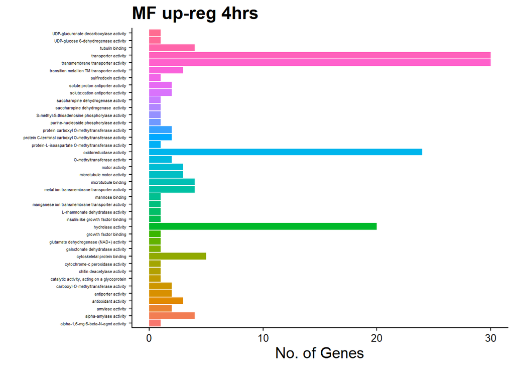

```r
Up4MF <- ggplot(U4_MF, aes(genes,description,  fill = description))+
         geom_bar(stat = "identity")+
                  labs(title = "MF up-reg 4hrs",
                            x = "No. of Genes",
                            y = "")+
          theme(legend.position ="none")+
          theme(text = element_text(size = 15))+
          theme(axis.text.y = element_text(size= 4))+
  theme(
    panel.grid.major = element_blank(),
    panel.grid.minor = element_blank()
  )

print(Up4MF)
```

```r
ggsave("~/GitHub/CryptoGat201RNASeq_draft_b/GOresults/MF_up4.png", width = 8, height = 5)
```

## Cellular Component

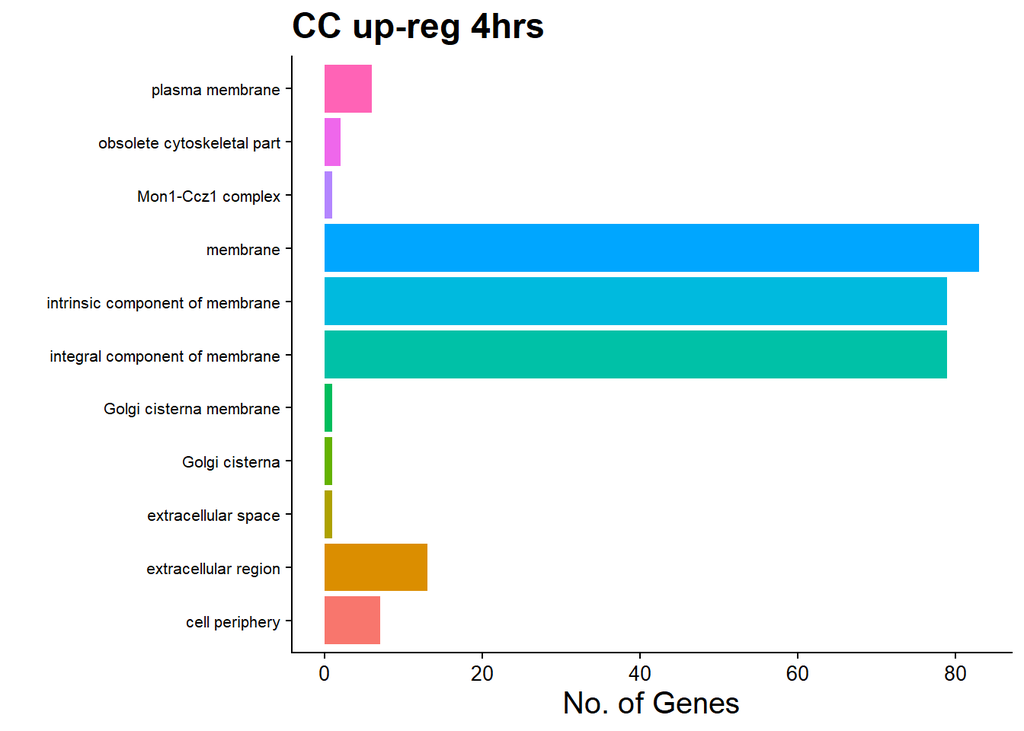

```r
Up4CC <- ggplot(U4_CC, aes(genes,description,  fill = description))+
         geom_bar(stat = "identity")+
                  labs(title = "CC up-reg 4hrs",
                            x = "No. of Genes",
                            y = "")+
          theme(legend.position ="none")+
          theme(text = element_text(size = 15))+
          theme(axis.text.y = element_text(size= 8))+
          scale_color_brewer(palette="Set1")+
  theme(
    panel.grid.major = element_blank(),
    panel.grid.minor = element_blank()
  )

print(Up4CC)
```

```r
ggsave("~/GitHub/CryptoGat201RNASeq_draft_b/GOresults/CC_up4.png", width = 8, height = 5)
```

## Combine all 3 GO groups up regulated (BP, MF, CC)

```r
Upreg4_all <- rbind(U4_BP, U4_MF, U4_CC)

head(Upreg4_all)
```

```
## # A tibble: 6 x 12
##   ID         description    `Bgd count` genes `Result gene list`    `Pct of bgd`
##   <chr>      <chr>                <dbl> <dbl> <chr>                        <dbl>
## 1 GO:0034605 cellular resp~         127    17 CNAG_00691,CNAG_0108~         13.4
## 2 GO:0006950 response to s~         467    38 CNAG_00654,CNAG_0069~          8.1
## 3 GO:0050896 response to s~         651    47 CNAG_00332,CNAG_0037~          7.2
## 4 GO:0009266 response to t~         164    19 CNAG_00691,CNAG_0108~         11.6
## 5 GO:0009408 response to h~         164    19 CNAG_00691,CNAG_0108~         11.6
## 6 GO:0055085 transmembrane~         350    29 CNAG_00303,CNAG_0053~          8.3
## # ... with 6 more variables: Fold enrichment <dbl>, Odds ratio <dbl>,
## #   P-value <dbl>, Benjamini <dbl>, Bonferroni <dbl>, GO_group <chr>
```

```r
Upreg4_all <- transform(Upreg4_all,description=factor(description,levels=unique(description)))

#Upreg4_all$description <- factor(Upreg4_all$description , levels = Upreg4_all$description )
```

## Plot all 3 GO upregulated

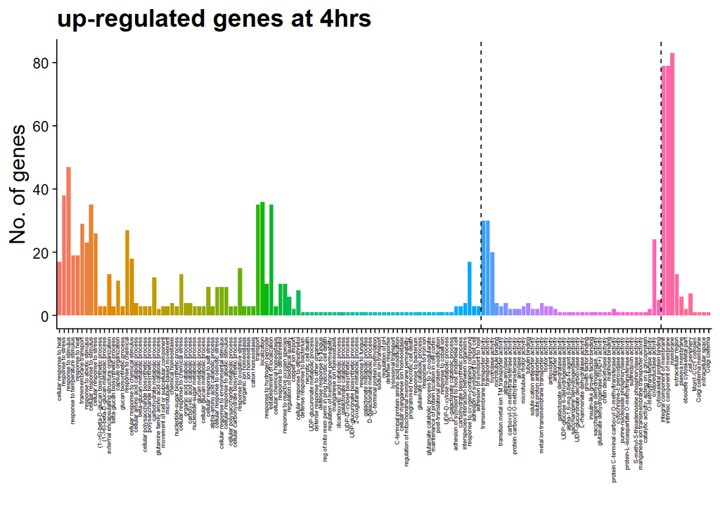

```r
Up4all <- ggplot(Upreg4_all , aes(description, genes, fill = description))+
         geom_bar(stat = "identity")+
                  labs(title = "up-regulated genes at 4hrs",
                            x = "",
                            y = "No. of genes")+
          theme(legend.position ="none")+
          theme(text = element_text(size = 15))+
          theme(axis.text.x = element_text(size= 4, angle = 90,hjust=1,vjust=0.2))+
          scale_color_brewer(palette="Set1")+
  geom_vline(xintercept=94.5, linetype="dashed", color = "black")+
  geom_vline(xintercept=134.5, linetype="dashed", color = "black")+
  theme(
    panel.grid.major = element_blank(),
    panel.grid.minor = element_blank()
  )

print(Up4all )
```

```r
ggsave("~/GitHub/CryptoGat201RNASeq_draft_b/GOresults/Up4all.png", width = 8, height = 5)
```

# Down regulated

```r
D4_BP <- readr::read_csv("../GOresults/BP_dn4.csv")
D4_MF <- readr::read_csv("../GOresults/MF_dn4.csv")
D4_CC <- readr::read_csv("../GOresults/CC_dn4.csv")
```

```r
D4_BP['GO_group'] <- "BP"
D4_MF['GO_group'] <- "MF"
D4_CC['GO_group'] <- "CC"
```

## Biological Process

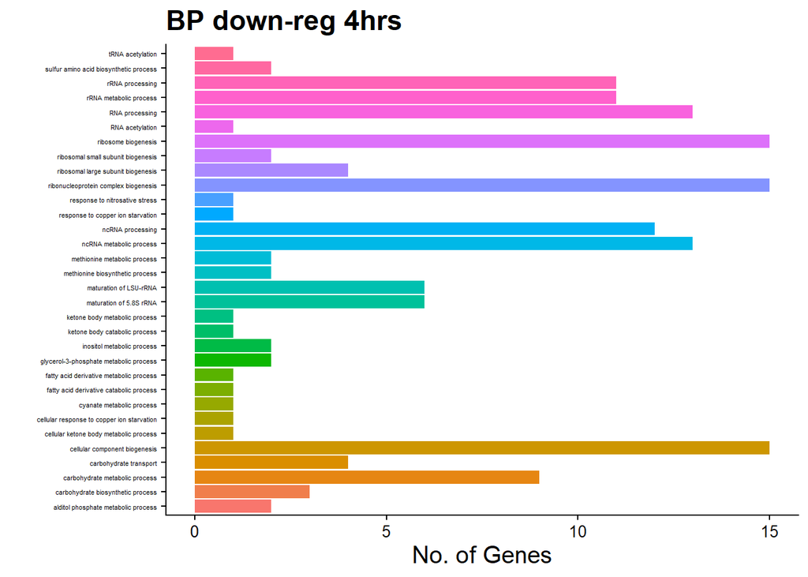

```r
Dn4BP <- ggplot(D4_BP, aes(genes,description,  fill = description))+
         geom_bar(stat = "identity")+
                  labs(title = "BP down-reg 4hrs",
                            x = "No. of Genes",
                            y = "")+
          theme(legend.position ="none")+
          theme(text = element_text(size = 15))+
          theme(axis.text.y = element_text(size= 4))+
  theme(
    panel.grid.major = element_blank(),
    panel.grid.minor = element_blank()
  )


print(Dn4BP)
```

```r
ggsave("~/GitHub/CryptoGat201RNASeq_draft_b/GOresults/BP_down4.png", width = 8, height = 5)
```

## Molecular Function

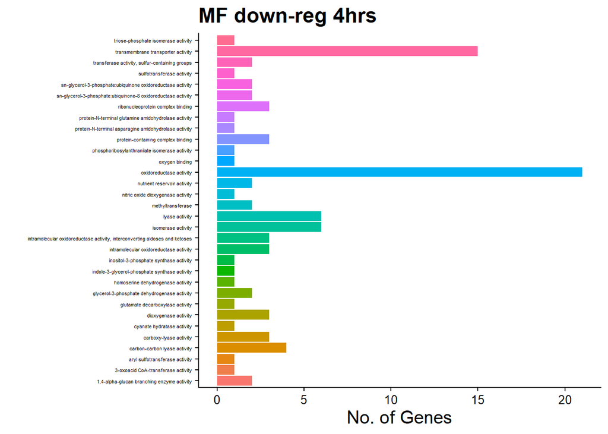

```r
Dn4MF <- ggplot(D4_MF, aes(genes,description,  fill = description))+
         geom_bar(stat = "identity")+
                  labs(title = "MF down-reg 4hrs",
                            x = "No. of Genes",
                            y = "")+
          theme(legend.position ="none")+
          theme(text = element_text(size = 15))+
          theme(axis.text.y = element_text(size= 4))+
  theme(
    panel.grid.major = element_blank(),
    panel.grid.minor = element_blank()
  )

print(Dn4MF)
```

```r
ggsave("~/GitHub/CryptoGat201RNASeq_draft_b/GOresults/MF_down4.png", width = 8, height = 5)
```

## Cellular Component

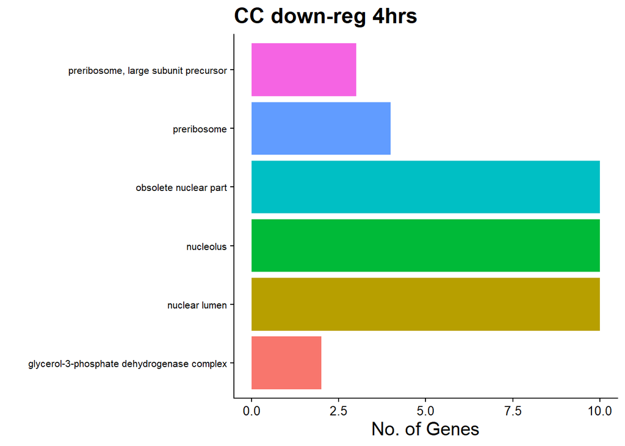

```r
Dn4CC <- ggplot(D4_CC, aes(genes,description,  fill = description))+
         geom_bar(stat = "identity")+
                  labs(title = "CC down-reg 4hrs",
                            x = "No. of Genes",
                            y = "")+
          theme(legend.position ="none")+
          theme(text = element_text(size = 15))+
          theme(axis.text.y = element_text(size= 8))+
          scale_color_brewer(palette="Set1")+
  theme(
    panel.grid.major = element_blank(),
    panel.grid.minor = element_blank()
  )

print(Dn4CC)
```

```r
ggsave("~/GitHub/CryptoGat201RNASeq_draft_b/GOresults/CC_down4.png", width = 8, height = 5)
```

## Combine all 3 GO groups down regulated (BP, MF, CC)

```r
Dnreg4_all <- rbind(D4_BP, D4_MF, D4_CC)

head(Dnreg4_all)
```

```
## # A tibble: 6 x 12
##   ID         description    `Bgd count` genes `Result gene list`    `Pct of bgd`
##   <chr>      <chr>                <dbl> <dbl> <chr>                        <dbl>
## 1 GO:0042254 ribosome biog~         103    15 CNAG_01564,CNAG_0232~         14.6
## 2 GO:0022613 ribonucleopro~         123    15 CNAG_01564,CNAG_0232~         12.2
## 3 GO:0006364 rRNA processi~          70    11 CNAG_03293,CNAG_0362~         15.7
## 4 GO:0016072 rRNA metaboli~          70    11 CNAG_03293,CNAG_0362~         15.7
## 5 GO:0000466 maturation of~           3     3 CNAG_03624,CNAG_0397~        100
## 6 GO:0000460 maturation of~           3     3 CNAG_03624,CNAG_0397~        100
## # ... with 6 more variables: Fold enrichment <dbl>, Odds ratio <dbl>,
## #   P-value <dbl>, Benjamini <dbl>, Bonferroni <dbl>, GO_group <chr>
```

```r
Dnreg4_all <- transform(Dnreg4_all,description=factor(description,levels=unique(description)))
```

## Plot all 3 GO down -regulated

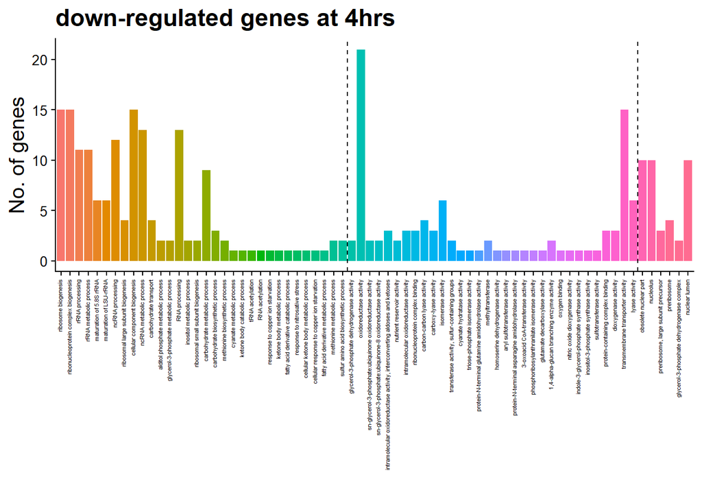

```r
Dn4all <- ggplot(Dnreg4_all , aes(description, genes, fill = description))+
         geom_bar(stat = "identity")+
                  labs(title = "down-regulated genes at 4hrs",
                            x = "",
                            y = "No. of genes")+
          theme(legend.position ="none")+
          theme(text = element_text(size = 15))+
          theme(axis.text.x = element_text(size= 4, angle = 90,hjust=1,vjust=0.2))+
  geom_vline(xintercept=32.5, linetype="dashed", color = "black")+
  geom_vline(xintercept=64.5, linetype="dashed", color = "black")+
          scale_color_brewer(palette="Set1")+
  theme(
    panel.grid.major = element_blank(),
    panel.grid.minor = element_blank()
  )

print(Dn4all )
```

```r
ggsave("~/GitHub/CryptoGat201RNASeq_draft_b/GOresults/Dn4all.png", width = 8, height = 5)
```